# Statistical Mechanics

## Classical Harmonic Oscillator

### Microcanonical ensemble

$1 = \int d^{6N}\mu \rho = C'\cdot A$, for $A=\int_{E \leq \sum_{i}^{3N}\frac{p_i^2}{2m}+\frac{kq_i^2}{2}\leq E+\delta E} dq_1...q_n,p_1...p_n$

To evaluate this integral, we can note that for $\tilde{\Omega}(E)=\int_{\sum_{i}^{3N}\frac{p_i^2}{2m}+\frac{kq_i^2}{2}\leq E} dq_1...q_n,p_1...p_n$, we have that $A=\tilde{\Omega}(E+\delta E)-\tilde{\Omega}(E)$.

$\tilde{\Omega}(E)$ is can be obtained by the formula for the volume of a sphere, and a change of variables to $(\frac{p_1}{\sqrt{m}}...\frac{p_n}{\sqrt{m}},\sqrt{k}q_1...\sqrt{k}q_n)$, which incurs a Jacobian determinant of $(\frac{m}{k})^{\frac{3N}{2}}$. In particular:

$$\tilde{\Omega}(E) = \int_{\sum_{i}^{3N}(\frac{p_i}{\sqrt{m}})^2+(\sqrt{k}q_i)^2\leq 2E} dq_1...dq_n,dp_1...dp_n = (\frac{m}{k})^{\frac{3N}{2}} \int_{\sum_{i}^{3N}(\frac{p_i}{\sqrt{m}})^2+(\sqrt{k}q_i)^2\leq 2E} d\frac{p_1}{\sqrt{m}}...d\frac{p_n}{\sqrt{m}},d\sqrt{k}q_1...d\sqrt{k}q_n = (\frac{m}{k})^{\frac{3N}{2}} Sph(6N,\sqrt{2E})$$

$$=\sqrt{\frac{m}{k}}^{3N}\frac{\pi^{3N}(2E)^{3N}}{\Gamma(3N+1)}$$

So in the limit of small $\Delta E$, we have that $\frac{A}{\Delta E}=\frac{\partial A}{\partial E} = \sqrt{\frac{m}{k}}^{3N}\frac{\pi^{3N}(2E)^{3N}}{\Gamma(3N+1)}=\frac{6N\sqrt{\frac{m}{k}}^{3N}\pi^{3N}(2E)^{3N-1}}{\Gamma(3N+1)}$

Then, again in the limit of small $\Delta E$, $C'=\frac{1}{\Delta E}\frac{\Gamma(3N+1)}{6N\sqrt{\frac{m}{k}}^{3N}\pi^{3N}(2E)^{3N-1}}$

### Canonical ensemble

Let's consider a single, 1D classical harmonic oscillator. I use $\mu$ to denote a point in phase space, with coordinates $(p,q)$. Assume units where $k_B$ is $1$.

$$H(q,p)=\frac{p^2}{2m}+\frac{kq^2}{2}$$

$$Z = \int e^{-\beta H(\mu)}d\mu = \left(\int_{\RR} dp e^{-\beta T(p)}\right)\cdot\left( \int_{\RR} e^{-\beta V(q)} \right) = \sqrt{\frac{2m\pi}{\beta}}\cdot \sqrt{\frac{2\pi}{\beta k}} = \frac{2\pi}{\omega\beta}$$

where $\omega$ is $\sqrt{\frac{k}{m}}$, which is the frequency of the oscillator.

So $E = -\frac{\partial \log Z(\beta)}{\partial\beta} = \frac{1}{\beta} \Rightarrow E = T$

This means that for *any spring constant*, the oscillator is equal to the temperature. This turns out not to be the correct model for nature: it turns out that at low temperatures and high spring constants, heat capacity decreases. Explaining this requires quantum mechanics.

## Classical ideal gas

Let $m$ be the mass of a single particle, and assume we have $N$ non-interacting particles trapped in a volume $V$. Let $U$ be the potential function, so that $U(q_i)=0$ if the particle is in the box, and $\infty$ otherwise.

### Fixed energy (microcanonical)

First choose some value of $E$. Then:

$$N!h^{3N}\rho(p,q) = \frac{1}{\Omega(E)}$$

where $$\Omega(E) = \int_{E \leq H(p,q) \leq E + \Delta E} dp_i\ldots dp_n,dq_i\ldots dq_n = \int_{E \leq \sum_i^{3N}\frac{p_i^2}{2m} + U(q_i) \leq E + \Delta E} dp_i\ldots dp_n,dq_i\ldots dq_n $$

$$ = \int_{\sum_i^{3N}\frac{p_i^2}{2m} + U(q_i) \leq E + \Delta E} dp_i\ldots dp_n,dq_i\ldots dq_n - \int_{\sum_i^{3N}\frac{p_i^2}{2m} + U(q_i) \leq E} dp_i\ldots dp_n,dq_i\ldots dq_n = \tilde{\Omega}(E+\Delta E) - \tilde{\Omega}(E) $$

where $\tilde{\Omega}(J) = \int_{\sum_i^{3N}\frac{p_i^2}{2m} + U(q_i) \leq J} \frac{1}{\Omega(E)} dp_i\ldots dp_n,dq_i\ldots dq_n $.

Note that

$$\tilde{\Omega}(J) = V^N\cdot Vol(S_{3N,\sqrt{J}})$$

where the volume of the d-sphere with radius $R$ is $Vol(S_{d,R})=\frac{\pi^{\frac{d}{2}}\sqrt{2mE}^{d}}{\Gamma(\frac{d}{2}+1)}$

Since $\Delta E$ is differentially small, we have:

$$ \frac{1}{\Delta E}N!h^{3N}\rho(p,q) = \frac{\tilde{\Omega}(E+\Delta E) - \tilde{\Omega}(E) }{\Delta E} \to \tilde{\Omega}'(E) $$

Then:

$$\tilde{\Omega}'(E) = \frac{d}{dE}V^N\frac{\pi^{\frac{3N}{2}}\sqrt{2mE}^{3N}}{\Gamma(\frac{3N}{2}+1)} = \frac{3N}{2}\cdot 2m\cdot V^N\frac{\pi^{\frac{3N}{2}}(2mE)^{\frac{3N}{2}-1}}{\Gamma(\frac{3N}{2}+1)} = \frac{3N}{2E} \cdot V^N\frac{(2\pi mE)^{\frac{3N}{2}}}{\Gamma(\frac{3N}{2}+1)} = \frac{1}{E} \cdot V^N\frac{(2\pi mE)^{\frac{3N}{2}}}{\Gamma(\frac{3N}{2})} $$

And putting it all together:

$$ \rho(p,q) = \Delta E\frac{1}{EN!h^{3N}} \cdot V^N\frac{(2\pi mE)^{\frac{3N}{2}}}{\Gamma(\frac{3N}{2})} $$

### Fixed temperature (canonical)

Since particles are independent, $Z=\frac{Z_i^N}{N!}$

$$Z_1(\beta) = \frac{1}{h^{3}} \int e^{-\beta H(p,q)} dp_i\ldots dp_n,dq_i\ldots dq_n = V^N\cdot \left(\int_{-\infty}^{\infty} e^{\frac{-\beta p_i^2}{2m}}\right)^{3} = V\cdot\left(\frac{\sqrt{2\pi mT}}{h}\right)^3 = V\cdot\left(\frac{\sqrt{mT}}{\sqrt{2\pi}\hbar}\right)^3 = V\cdot\left(\frac{mT}{2\pi\hbar^2}\right)^{\frac{3}{2}} $$

Defining the thermal de-Broglie wavelength as:

$$\lambda = \left(\frac{2\pi\hbar^2}{mT}\right)^{\frac{1}{2}}$$

with dimensions, where $E=ML^2T^{−2}$, of $\left(E^2T^2M^{-1}E^{-1}\right)^{\frac{1}{2}} = \left(ML^2T^{−2}T^2M^{-1}\right)^{\frac{1}{2}}=L $

we then have:

$$ Z_i(\beta) = \frac{V}{\lambda^3}$$

$$ p = -\pd{A}{V} = -\pd{-T\log Z}{V} = NT\pd{}{V}\log V = \frac{NT}{V}$$

(This is the usually seen as $pV = Nk_BT$.)

$$ E = -\pd{\log Z}{\beta} = \frac{3}{2}NT$$

Then note that energy per particle is then $\frac{3}{2}T=\frac{\dot{q}^2}{2m}$, where $\dot{q}$ is the momentum of a single particle, so that $\sqrt{3Tm}=\dot{q}$

But recalling that $\lambda_{dB}=\frac{h}{p}$ is the de Broglie wavelength, we see why $\lambda$ is called the thermal de Broglie wavelength, since it is, up to a constant, the wavelength of the average particle.

### Equation of state

The equation of state for the ideal gas is known as the Sackur-Tetrode formula. We can derive it as follows:

$$ S = -\pd{A}{T} = \pd{}{T} T\left(\log \left(\frac{V}{\lambda^3}\right)^N - \log N!\right) = \pd{}{T} T\left(\log \left(\frac{V}{\lambda^3}\right)^N - N\log N + N \right) = \pd{}{T} TN\left(\log \left(\frac{V}{\lambda^3}\right) - \log N + 1 \right) $$

$$ = \pd{}{T} TN\left(\log \left(\frac{V}{N\lambda^3}\right) + 1 \right) $$

Now note that $\pd{}{T} N\left(\log \left(\frac{V}{N\lambda^3}\right) + 1 \right) = -N\pd{}{T}\log(\lambda^3)=-N\pd{}{T}\log\left(\frac{2\pi\hbar^2}{mT}\right)^{\frac{3}{2}}=\frac{3}{2}N$

so

$$ S = \pd{}{T} TN\left(\log \left(\frac{V}{N\lambda^3}\right) + 1 \right) = N\left(\log \left(\frac{V}{N\lambda^3}\right) + \frac{5}{2} \right) $$

### Quantum Harmonic Oscillator

The state space is $\mathbb{N}$, the natural numbers, with $E(n)=(n+\frac{1}{2})\hbar\omega$. Then:

$$Z = \sum_{n=0}^{\infty} e^{-\beta(n+\frac{1}{2})\hbar\omega} = e^{-\beta\frac{1}{2}\hbar\omega}\sum_{n=0}^{\infty} \left(e^{-\beta \hbar\omega}\right)^n = e^{-\beta\frac{1}{2}\hbar\omega} \frac{1}{1- e^{-\beta \hbar\omega}} = \frac{1}{e^{\frac{\beta\hbar\omega}{2}}- e^{-\frac{\beta \hbar\omega}{2}}} $$

Proceeding in the normal fashion, we obtain as energy and heat capacity:

$$ E = \hbar\omega\left( \frac{1}{2} + \frac{1}{e^{\beta\hbar\omega}-1} \right) $$

$$ C_v = \frac{\omega ^2 \hbar ^2 e^{\frac{\omega \hbar }{T}}}{T^2 \left(e^{\frac{\omega \hbar }{T}}-1\right)^2} $$

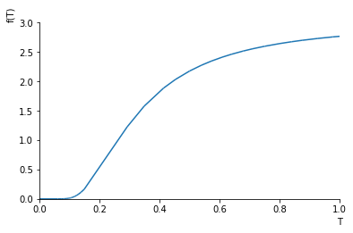

```
<sympy.plotting.plot.Plot at 0x115229e80>
```

```python
# C_v plot
plot(3*(1/T)**2*sp.exp(1/T)/((exp(1/T)-1)**2),xlim=(0,1))
```

At low $T$, we can see that $E$ becomes increasingly constant (in $T$), but at high $T$, becomes linear in $T$ (you need to consider the locally linear region near $\beta=0$, since otherwise we get division by $0$. This is the thermodynamic behaviour predicted by the corresponding classical model.

Further note that $\omega = \sqrt{\frac{k}{m}}$, so similar remarks hold for oscillators with a strong spring constant, for example.

**Note**: one example of a physically useful consequence of this: a gas of diatomic molecules should have vibrational energy from the molecules (which are harmonic oscillators), but if their spring constant is high enough relative to the temperature of the system, we can treat them as frozen. More generally, we get locking of certain degrees of freedom. This explains why macroscopic systems have lower energy than classical statistical mechanics predicts, and similarly the heat capacity of solids (lattices of harmonic oscillators) was overestimated classically. Another example is a vibrating string. If each complex exponential (harmonic oscillator) in its Fourier series had energy equal to the temperature, the total energy would be unbounded. We need instead to say that the high frequency oscillators have exponentially small temperature.

## Models of solids

For simplicity, assume we have a 1D lattice (same ideas apply in 3D). The configuration of the lattice can be represented by a vector $\textbf{q}$, giving the displacement from equilibrium of each atom. Moreover assume periodic boundary conditions so that $q_{N+1}=q_N$. Kinetic energy is then straightforward, namely $\sum_i^N \frac{p_i^2}{2m}$.

The problem is the potential, which could be enormously complex. What we can do is to consider the low temperature case, where displacements are small, and so a Taylor expansion is justified, with:

$$ U(q) \approx U(q_0) +\left(q-q_0\right)\left(\nabla U|_{q_0}\right) + \left(q-q_0\right)^T\left(\nabla^2U|_{q_0} \right)\left(q-q_0\right) $$

We can then diagonalize $H=\left(\nabla^2U|_{q_0} \right)$ to obtain a new formula for $N$ independent oscillators, which allows us to express the partition function as a sum of independent harmonic oscillators (either quantum or classical).

The next step is to approximate the sum by an integral, which requires us to provide a density $\sigma(\omega)d\omega$ over frequencies for our harmonic oscillators. Notice that this is a continuum approximation of the solid.

The Debye model provides one choice of $\sigma$.

The much simpler Einstein model of a solid, which qualitatively captures the fact that the heat capacity drops with temperature, is to treat a solid as a set of $3N$ harmonic oscillators, all sharing the same $\omega$.

## Gas with quantized energy levels

([These lecture notes](https://ps.uci.edu/~cyu/p115A/LectureNotes/Lecture13/lecture13.pdf) were helpful here)

Suppose that we have $N$ particles, energy levels denoted $e(i)$, and number of particles per level denoted $R(n_i)$ (in a full state of the system $R$. Then $N=\sum_ie(i)R_n(i)$ in that state. Assume that temperature (and chemical potential) are fixed.

$$ \langle n_j \rangle = \frac{1}{\sum_R e^{-\beta\sum_ie(i)R(n_i)}}\sum_R R(n_j) e^{-\beta\sum_ie(i)R(n_i)} = -\frac{1}{\beta}\pd{}{e(j)}\log Z $$

Then under different assumptions we obtain different values of $Z$, and can proceed from there.

### With distinguishable particles (Maxwell-Boltzmann statistics)

If the particles are distinguishable, we have:

$$ \log Z = \log \xi^N = N \log \xi $$

where $\xi = \sum_ie^{-\beta e(i)}$

Then

$$ \langle n_j \rangle = -\frac{1}{\beta}\pd{}{e(j)}\log Z = -\frac{1}{\beta}\pd{}{e(j)}N\log \sum_ie^{-\beta e(i)} = N \frac{e^{-\beta e(j)}}{\sum_ie^{-\beta e(i)}} $$

### With indistinguishable bosons (Planck)

### With indistinguishable bosons with no fixed number (Bose-Einstein statistics)

Here we have to use the Grand Canonical Ensemble, namely:

with $R(E) = \sum_ie(i)R(n_i)$ and $R(N) = \sum_i R(n_i)$:

$$\mathcal{Z} = \sum_R e^{-\beta (R(e) - \mu R(N) )} = \sum_R e^{-\beta (\sum_i e(i)R(n_i) - \mu R(n_i) )} = \sum_{n_1=0}^{\infty} e^{-\beta(e(1)-\mu)n_1}\cdot\sum_{n_2=0}^{\infty} e^{-\beta(e(2)-\mu)n_2}\ldots $$

$$ = \frac{1}{1- e^{-\beta(e(1)-\mu)}}\cdot \frac{1}{1- e^{-\beta(e(2)-\mu)}}\ldots $$

So

$$ \log \mathcal{Z} = -\sum_{r=1}^{\infty} \log(1 - e^{-\beta(e(1)-\mu)}) $$

and

$$ \langle N \rangle = \frac{1}{\beta}\pd{}{\mu}\log \mathcal{Z} = \sum_{r=1}^{\infty} \frac{e^{-\beta(e(r)-\mu)}}{(1 - e^{-\beta(e(r)-\mu)})} = \sum_{r=1}^{\infty} \frac{1}{e^{\beta(e(r)-\mu)} - 1} $$

Similarly: $\langle n_j \rangle = \frac{1}{e^{\beta(e(j)-\mu)} - 1} $

Note that since $\forall j: \langle n_j \rangle \gt 0$, we have $\forall j: E_j\gt \mu$. In particular, as $\mu$ approaches the lowest energy $E_0$, $\langle n_0 \rangle \to \infty$ and so almost all of the particles reside in the ground state. This is Bose-Einstein condensation, and leads to weird macroscopic effects of quantum behaviour.

### With indistinguishable fermions with no fixed number (Fermi-Dirac statistics)

Now assume the particles are Fermions. Proceeding in the same fashion, but summing $n_i$ up to $1$, not to infinity, in order to respect the Pauli exclusion principle for Fermions, we obtain:

$$ \langle n_j \rangle = \frac{1}{e^{\beta(e(j)-\mu)} + 1} $$

This is a useful model of electron and hole density in semiconductors. Note that $\langle n_j \rangle \leq 1$, as we would want.

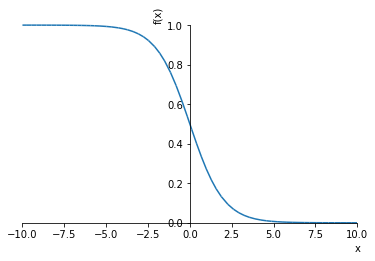

```
<sympy.plotting.plot.Plot at 0x1150320f0>
```

```python
x = sp.symbols("x")
plot(1 / (sp.exp(x) + 1))
```

### Relaxation from quantum to classical

Assume the temperature is large in either a boson or fermion gas, but fix $N$. Then high energy states become popular, and $e^{-\beta(e(j)-\mu)}$ must become small, in order to keep $N$ constant.

$$\langle n_j \rangle = \frac{1}{e^{\beta(e(j)-\mu)} \pm 1} \to e^{-\beta(e(j)-\mu)} $$

But note that

$$ \langle N \rangle = \sum_i \langle n_i \rangle = \sum_ie^{-\beta(e(j)-\mu)} = e^{\beta\mu}\sum_ie^{-\beta e(j)} $$

$$ \Rightarrow \langle n_i \rangle = e^{-\beta(e(j)-\mu)} = e^{-\beta e(j)}e^{\beta\mu} = e^{-\beta e(j)}\frac{\langle N \rangle}{\sum_ie^{-\beta e(j)}} $$

Further, $\langle N \rangle$ converges to $N$, and so we get the Maxwell-Boltzmann statistics.

## Simple random walk

The simplest random walk is a series $n$ of independent unbiased Bernoulli trials, so if $X\sim Bin(p=0.5,n=n)$, then $Y = 2X-1$ is the random variable corresponding to the observable of length of chain, if we're modeling a polymer chain for example.

## Deriving the diffusion equation

For a simple random walk, we can describe not only the macroscopic equilibrium state, but also the approach to equilibrium, which is diffusion.

For a density $\rho(x,t)$, the following equation describes diffusion:

$$ \frac{\partial \rho}{\partial t} = a\frac{\partial^2 \rho}{\partial x^2} $$

This can be seen to be the continuum limit of random walks. The following derivation is from Sethna's excellent *Statistical Mechanics: Entropy, Order Parameters, and Complexity*.

Let $X(t)$ be the random variable (with density $\rho(x, t)$) for a particle's position at time $t$, and assume a discrete time step $\Delta t$, so that $X(t+\Delta t)=X(t)+L$, where $L$ is a random variable representing a step, with $E[L]=0$ and density $\chi$.

The density $\rho(x, t+\Delta t)$ is then the sum of the random variables $X(t)$ and $L$, which is the convolution of their densities:

$$\rho(x, t+\Delta t) = \int_{-\infty}^{\infty}\rho(x-z,t)\cdot \chi(z)dz$$

If we assume that the step size is very small compared to the varying of $\rho$ with $x$ then we can Taylor expand:

$$\rho(x, t+\Delta t) = \int_{-\infty}^{\infty}\left( \rho(x,t)-\frac{\partial \rho}{\partial x}z + \frac{\partial^2\rho}{\partial x^2}\frac{z^2}{2} \right)\cdot \chi(z)dz$$

$$ = \rho(x,t)\int_{-\infty}^{\infty}\chi(z)dz - \frac{\partial \rho}{\partial x}\int_{-\infty}^{\infty}\left(z \right)\cdot \chi(z)dz + \frac{1}{2}\frac{\partial^2\rho}{\partial x^2}\int_{-\infty}^{\infty}\left(z^2 \right)\cdot \chi(z)dz $$

$$ = \rho + \frac{1}{2}\frac{\partial^2\rho}{\partial x^2}\cdot Var[L] $$

Now suppose that we also assume that $\rho$ changes very little in each time step. Then, in the limit we can equate $\rho(x,t+\Delta t)-\rho(x,t)$ with $\frac{\partial\rho}{\partial t}\Delta t$

Putting together these two interpretations for $\rho(x,t+\Delta t)$ gives:

$$\frac{\partial\rho}{\partial t}= \frac{Var[L]}{2\Delta t} \frac{\partial^2\rho}{\partial x^2} $$

which not only derives the diffusion equation, but gives us the form of $a$.

### Conserved current

A closely connected relation between discrete and continuum systems is as follows: let $\rho(x)\Delta x$ be the density of the quantity of interest, and $J(x)$ the rate of this quantity moving through $x$. Then

$$\frac{d \rho(x)\Delta x}{dt} = J(x)-J(x+\Delta x) \Rightarrow \frac{d \rho(x)}{dt} = -\frac{J(x+\Delta x)-J(x)}{\Delta x} \to -\frac{dJ}{dx} $$

Given conserved current and a further assumption that $J=-a\frac{\partial \rho}{\partial t}$, we recover the diffusion equation. This second assumption is, Sethna notes, sensible in the context of perturbations of equilibrium systems, which can be studied more formally.